# Final Project: Airline Satisfaction

Author

Tyler Johnston

Published

May 7, 2026

### Setup Chunk

```r
library(tidyverse)
library(tidymodels)

# Missingness packages
library(mice)
library(naniar, exclude = "n_complete")

source("https://github.com/jjcurtin/lab_support/blob/main/fun_eda.R?raw=true")
source("https://github.com/jjcurtin/lab_support/blob/main/fun_plots.R?raw=true")

options(conflicts.policy = "depends.ok")

path_data <- "Psych_752/Application Exams/Data"
```

Loading necessary packages, setting conflict policy, and defining a path.

## EDA

### Data Loading & Cleaning

```r
data <- read_csv(here::here(path_data, "airline_passenger_satisfaction.csv")) |>
  janitor::clean_names() |>
  glimpse()
```

```
Rows: 600
Columns: 24
$ id                                <dbl> 94031, 81130, 1431, 42411, 33339, 67…
$ gender                            <chr> "Male", "Male", "Female", NA, "Femal…
$ customer_type                     <chr> "Loyal Customer", "Loyal Customer", …
$ age                               <dbl> 32, 18, 43, 53, 25, 58, 51, 42, 44, …
$ type_of_travel                    <chr> "Business travel", "Business travel"…
$ customer_class                    <chr> "Business", "Business", "Business", …
$ flight_distance                   <dbl> 1389, 3456, 2899, 2694, 2419, 421, 3…
$ inflight_wifi_service             <dbl> 2, 2, 0, 1, 5, 0, 5, 2, 1, 1, 2, 5, …
$ departure_arrival_time_convenient <dbl> 2, 2, 0, 1, 5, 3, 5, 2, 1, 1, 2, 5, …
$ ease_of_online_booking            <dbl> 2, 2, 0, 1, 5, 0, 5, 3, 1, 1, 2, 5, …
$ gate_location                     <dbl> 2, 2, 5, 1, 5, 3, 5, 2, 1, 1, 2, 5, …
$ food_and_drink                    <dbl> 5, 4, 4, 3, 5, 3, 4, 2, 2, 5, 5, 3, …
$ online_boarding                   <dbl> 5, 4, 5, 5, 5, 3, 5, 4, 5, 5, 5, 5, …
$ seat_comfort                      <dbl> 5, 4, 5, 4, 4, 3, 4, 4, 4, 5, 4, 5, …
$ inflight_entertainment            <dbl> 5, 4, 2, 4, 5, 4, 4, 4, 5, 5, 4, 5, …
$ onboard_service                   <dbl> 4, 4, 2, 4, 3, 4, 4, 4, 5, 3, 4, 5, …
$ leg_room_service                  <dbl> 5, 2, 2, 4, 3, 0, 4, 4, 5, 1, 4, 5, …
$ baggage_handling                  <dbl> 5, 1, 2, 4, 5, 4, 4, 4, 5, 3, 4, 5, …
$ checkin_service                   <dbl> 5, 3, 3, 3, 3, 3, 3, 4, 3, 2, 5, 5, …
$ inflight_service                  <dbl> 5, 3, 2, 4, 4, 4, 4, 4, 5, 4, 4, 5, …
$ cleanliness                       <dbl> 5, 4, 4, 3, 5, 3, 5, 3, 4, 5, 5, 5, …
$ departure_delay_in_minutes        <dbl> 67, 0, 6, 0, 3, 0, 0, 50, 8, 21, 21,…
$ arrival_delay_in_minutes          <dbl> 79, 0, 0, 0, 2, 0, 0, 42, 5, 4, 7, 1…
$ satisfaction                      <chr> "satisfied", "satisfied", "satisfied…
```

```r
data_clean <- data |>
  mutate(
    id = as.character(id)) |>
  mutate(
    gender = factor(gender,
                    levels = c("Male", "Female"),
                    labels = c("0", "1")),
    customer_type = factor(customer_type,
                           levels = c("disloyal Customer", "Loyal Customer"),
                           labels = c("0", "1")),
    type_of_travel = factor(type_of_travel,
                            levels = c("Business travel", "Personal Travel"),
                            labels = c("0", "1"))) |>
  mutate(
    customer_class = factor(customer_class,
                            levels = c("Eco", "Eco Plus", "Business"),
                            ordered = TRUE),
    satisfaction = factor(satisfaction,
                          levels = c("neutral or dissatisfied", "satisfied"),
                          labels = c("0", "1"))) |>
  glimpse()
```

```
Rows: 600
Columns: 24
$ id                                <chr> "94031", "81130", "1431", "42411", "…
$ gender                            <fct> 0, 0, 1, NA, 1, 1, 0, NA, 0, 0, 1, 1…
$ customer_type                     <fct> 1, 1, 1, 1, 1, 1, 1, 1, 1, 1, 1, 1, …
$ age                               <dbl> 32, 18, 43, 53, 25, 58, 51, 42, 44, …
$ type_of_travel                    <fct> 0, 0, 0, 0, 0, 1, 0, 0, 0, 0, 0, 0, …
$ customer_class                    <ord> Business, Business, Business, Busine…
$ flight_distance                   <dbl> 1389, 3456, 2899, 2694, 2419, 421, 3…
$ inflight_wifi_service             <dbl> 2, 2, 0, 1, 5, 0, 5, 2, 1, 1, 2, 5, …
$ departure_arrival_time_convenient <dbl> 2, 2, 0, 1, 5, 3, 5, 2, 1, 1, 2, 5, …
$ ease_of_online_booking            <dbl> 2, 2, 0, 1, 5, 0, 5, 3, 1, 1, 2, 5, …
$ gate_location                     <dbl> 2, 2, 5, 1, 5, 3, 5, 2, 1, 1, 2, 5, …
$ food_and_drink                    <dbl> 5, 4, 4, 3, 5, 3, 4, 2, 2, 5, 5, 3, …
$ online_boarding                   <dbl> 5, 4, 5, 5, 5, 3, 5, 4, 5, 5, 5, 5, …
$ seat_comfort                      <dbl> 5, 4, 5, 4, 4, 3, 4, 4, 4, 5, 4, 5, …
$ inflight_entertainment            <dbl> 5, 4, 2, 4, 5, 4, 4, 4, 5, 5, 4, 5, …
$ onboard_service                   <dbl> 4, 4, 2, 4, 3, 4, 4, 4, 5, 3, 4, 5, …
$ leg_room_service                  <dbl> 5, 2, 2, 4, 3, 0, 4, 4, 5, 1, 4, 5, …
$ baggage_handling                  <dbl> 5, 1, 2, 4, 5, 4, 4, 4, 5, 3, 4, 5, …
$ checkin_service                   <dbl> 5, 3, 3, 3, 3, 3, 3, 4, 3, 2, 5, 5, …
$ inflight_service                  <dbl> 5, 3, 2, 4, 4, 4, 4, 4, 5, 4, 4, 5, …
$ cleanliness                       <dbl> 5, 4, 4, 3, 5, 3, 5, 3, 4, 5, 5, 5, …
$ departure_delay_in_minutes        <dbl> 67, 0, 6, 0, 3, 0, 0, 50, 8, 21, 21,…
$ arrival_delay_in_minutes          <dbl> 79, 0, 0, 0, 2, 0, 0, 42, 5, 4, 7, 1…
$ satisfaction                      <fct> 1, 1, 1, 1, 1, 1, 1, 1, 1, 1, 1, 1, …
```

```r
data_nona <- data_clean |>
  drop_na()
```

After loading in the data and cleaning the names, we needed to clean the dataset itself.

1) All binary predictors were coded as labeled factors (0 and 1) to keep modeling smooth. 2) Customer class was treated as an ordered factor to preserve meaningful ordering but without assuming any specific spacing between levels. 3) All Likert-type scale variables (0-5) were left as numerics to allow for flexible modeling. 4) Outcome variable (satisfaction) was coded 0 (not satisfied/neutral) and 1 (satisfied).

Then I made a new dataset from this version that undergoes casewise deletion of missing values/NAs, this left us with just over 2/3rds of the cases since many had at least 1 missing value. We’ll retain both versions for now.

### Additional EDA

```r
data_clean |>
  skim_some()
```

Data summary

| Name | data_clean |
| --- | --- |
| Number of rows | 600 |
| Number of columns | 24 |
| _______________________ |  |
| Column type frequency: |  |
| character | 1 |
| factor | 5 |
| numeric | 18 |
| ________________________ |  |
| Group variables | None |

**Variable type: character**

| skim_variable | n_missing | complete_rate | min | max | empty | n_unique | whitespace |
| --- | --- | --- | --- | --- | --- | --- | --- |
| id | 0 | 1 | 3 | 6 | 0 | 600 | 0 |

**Variable type: factor**

| skim_variable | n_missing | complete_rate | ordered | n_unique | top_counts |
| --- | --- | --- | --- | --- | --- |
| gender | 117 | 0.80 | FALSE | 2 | 1: 262, 0: 221 |
| customer_type | 0 | 1.00 | FALSE | 2 | 1: 496, 0: 104 |
| type_of_travel | 0 | 1.00 | FALSE | 2 | 0: 480, 1: 120 |
| customer_class | 5 | 0.99 | TRUE | 3 | Bus: 359, Eco: 197, Eco: 39 |
| satisfaction | 0 | 1.00 | FALSE | 2 | 1: 400, 0: 200 |

**Variable type: numeric**

| skim_variable | n_missing | complete_rate | p0 | p100 |
| --- | --- | --- | --- | --- |
| age | 0 | 1.00 | 8 | 85 |
| flight_distance | 0 | 1.00 | 56 | 3989 |
| inflight_wifi_service | 0 | 1.00 | 0 | 5 |
| departure_arrival_time_convenient | 0 | 1.00 | 0 | 5 |
| ease_of_online_booking | 0 | 1.00 | 0 | 5 |
| gate_location | 0 | 1.00 | 1 | 5 |
| food_and_drink | 0 | 1.00 | 1 | 5 |
| online_boarding | 41 | 0.93 | 0 | 5 |
| seat_comfort | 0 | 1.00 | 1 | 5 |
| inflight_entertainment | 0 | 1.00 | 1 | 5 |
| onboard_service | 22 | 0.96 | 1 | 5 |
| leg_room_service | 0 | 1.00 | 0 | 5 |
| baggage_handling | 0 | 1.00 | 1 | 5 |
| checkin_service | 0 | 1.00 | 1 | 5 |
| inflight_service | 0 | 1.00 | 1 | 5 |
| cleanliness | 0 | 1.00 | 1 | 5 |
| departure_delay_in_minutes | 7 | 0.99 | 0 | 360 |
| arrival_delay_in_minutes | 3 | 1.00 | 0 | 409 |

```r
# Quite a bit of missingness (mostly from gender), let's see if we can determine type of missingness and potentially move forward without simply excluding all cases with any missing.

d <- data_clean |> select(gender, customer_class, customer_type, age, flight_distance, online_boarding, onboard_service, departure_delay_in_minutes, arrival_delay_in_minutes)

skimr::skim(d)
```

Data summary

| Name | d |
| --- | --- |
| Number of rows | 600 |
| Number of columns | 9 |
| _______________________ |  |
| Column type frequency: |  |
| factor | 3 |
| numeric | 6 |
| ________________________ |  |
| Group variables | None |

**Variable type: factor**

| skim_variable | n_missing | complete_rate | ordered | n_unique | top_counts |
| --- | --- | --- | --- | --- | --- |
| gender | 117 | 0.80 | FALSE | 2 | 1: 262, 0: 221 |
| customer_class | 5 | 0.99 | TRUE | 3 | Bus: 359, Eco: 197, Eco: 39 |
| customer_type | 0 | 1.00 | FALSE | 2 | 1: 496, 0: 104 |

**Variable type: numeric**

| skim_variable | n_missing | complete_rate | mean | sd | p0 | p25 | p50 | p75 | p100 | hist |
| --- | --- | --- | --- | --- | --- | --- | --- | --- | --- | --- |
| age | 0 | 1.00 | 39.97 | 14.08 | 8 | 28 | 40.5 | 51.0 | 85 | ▃▆▇▃▁ |
| flight_distance | 0 | 1.00 | 1318.55 | 1061.79 | 56 | 431 | 974.5 | 1998.5 | 3989 | ▇▅▂▂▂ |
| online_boarding | 41 | 0.93 | 3.56 | 1.33 | 0 | 3 | 4.0 | 5.0 | 5 | ▂▃▃▇▆ |
| onboard_service | 22 | 0.96 | 3.51 | 1.27 | 1 | 3 | 4.0 | 5.0 | 5 | ▂▃▆▇▇ |
| departure_delay_in_minutes | 7 | 0.99 | 13.82 | 37.28 | 0 | 0 | 0.0 | 9.0 | 360 | ▇▁▁▁▁ |
| arrival_delay_in_minutes | 3 | 1.00 | 13.51 | 38.21 | 0 | 0 | 0.0 | 8.0 | 409 | ▇▁▁▁▁ |

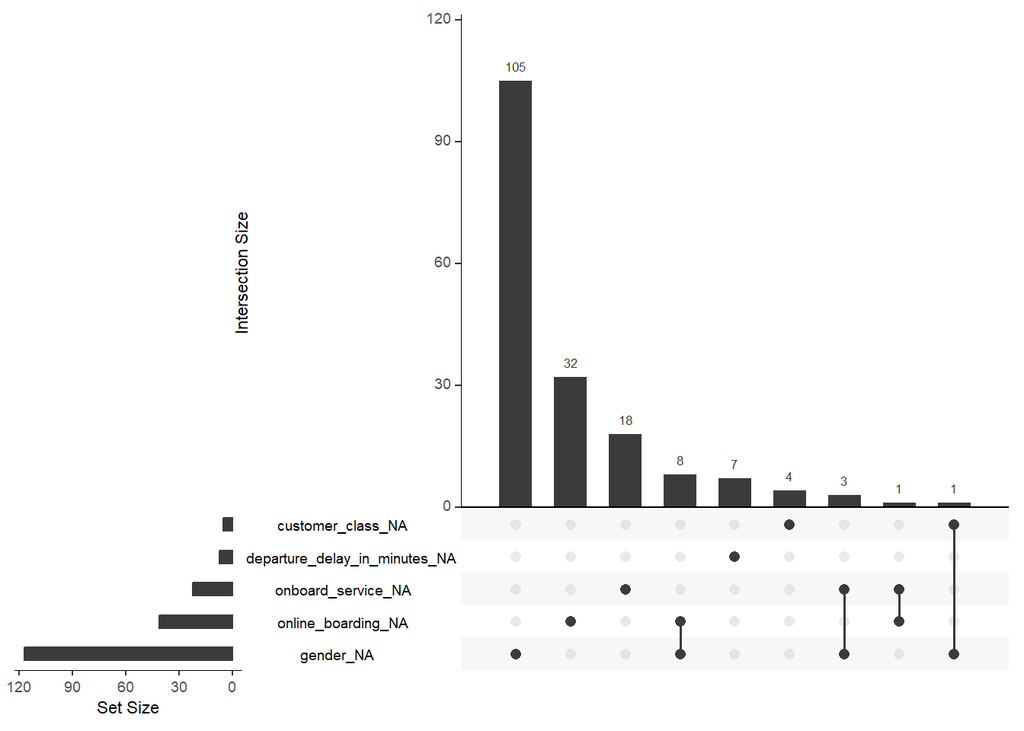

```r
gg_miss_upset(d)
```

Most missingness comes from gender, 105 of the 181 variables that are missing anything are only missing gender. 32 are missing only online boarding, 18 are missing only onboard_service, and very few (13) participants had missingness on more than 1 variable, with none having more than 2. Would be great to be able to retain gender by imputing realistic “values” using correlated variables, then we could compare performance of our eventual models trained on each version and see if imputation helps our model performance.

### Missingness EDA continued

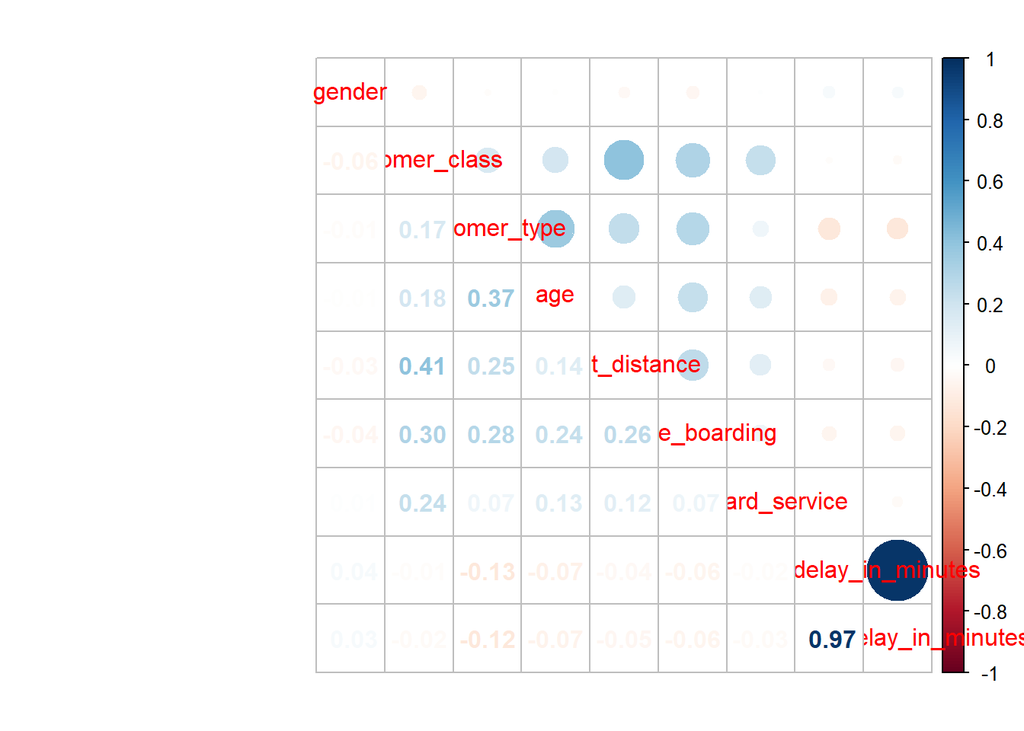

```r
d |>
  mutate(across(where(is.factor), ~ as.numeric(.))) |>
  cor(use = "pairwise.complete.obs") |>
  corrplot::corrplot.mixed()
```

Seems gender is not associated with any variables, so we’ll probably just have to drop all cases missing gender. Other variables don’t have much missingness so won’t try to impute for those either. We’ll use data_nona from here on out as we also have no reason to assume any coding errors for the NAs.

### Univariate EDA & Class Balance

```r
data_nona |>
  select(where(is.numeric)) |>
  summary()
```

```
      age        flight_distance  inflight_wifi_service
 Min.   : 8.00   Min.   :  67.0   Min.   :0.000
 1st Qu.:29.00   1st Qu.: 417.5   1st Qu.:2.000
 Median :41.00   Median : 946.0   Median :3.000
 Mean   :40.05   Mean   :1342.1   Mean   :2.907
 3rd Qu.:51.00   3rd Qu.:2111.0   3rd Qu.:4.000
 Max.   :76.00   Max.   :3989.0   Max.   :5.000
 departure_arrival_time_convenient ease_of_online_booking gate_location
 Min.   :0.000                     Min.   :0.000          Min.   :1.00
 1st Qu.:2.000                     1st Qu.:2.000          1st Qu.:2.00
 Median :3.000                     Median :3.000          Median :3.00
 Mean   :3.002                     Mean   :2.866          Mean   :3.01
 3rd Qu.:4.000                     3rd Qu.:4.000          3rd Qu.:4.00
 Max.   :5.000                     Max.   :5.000          Max.   :5.00
 food_and_drink  online_boarding  seat_comfort   inflight_entertainment
 Min.   :1.000   Min.   :0.00    Min.   :1.000   Min.   :1.000
 1st Qu.:2.000   1st Qu.:3.00    1st Qu.:3.000   1st Qu.:3.000
 Median :3.000   Median :4.00    Median :4.000   Median :4.000
 Mean   :3.301   Mean   :3.58    Mean   :3.644   Mean   :3.578
 3rd Qu.:4.000   3rd Qu.:5.00    3rd Qu.:5.000   3rd Qu.:5.000
 Max.   :5.000   Max.   :5.00    Max.   :5.000   Max.   :5.000
 onboard_service leg_room_service baggage_handling checkin_service
 Min.   :1.000   Min.   :0.000    Min.   :1.000    Min.   :1.000
 1st Qu.:3.000   1st Qu.:3.000    1st Qu.:3.000    1st Qu.:3.000
 Median :4.000   Median :4.000    Median :4.000    Median :3.000
 Mean   :3.547   Mean   :3.585    Mean   :3.768    Mean   :3.332
 3rd Qu.:5.000   3rd Qu.:5.000    3rd Qu.:5.000    3rd Qu.:4.000
 Max.   :5.000   Max.   :5.000    Max.   :5.000    Max.   :5.000
 inflight_service  cleanliness    departure_delay_in_minutes
 Min.   :1.000    Min.   :1.000   Min.   :  0.00
 1st Qu.:3.000    1st Qu.:3.000   1st Qu.:  0.00
 Median :4.000    Median :3.000   Median :  0.00
 Mean   :3.831    Mean   :3.322   Mean   : 13.97
 3rd Qu.:5.000    3rd Qu.:4.000   3rd Qu.:  8.00
 Max.   :5.000    Max.   :5.000   Max.   :360.00
 arrival_delay_in_minutes
 Min.   :  0.00
 1st Qu.:  0.00
 Median :  0.00
 Mean   : 13.45
 3rd Qu.:  6.50
 Max.   :409.00
```

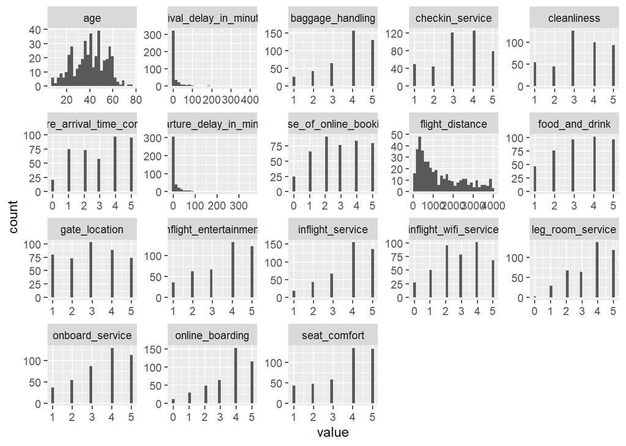

```r
data_nona |>
  pivot_longer(where(is.numeric)) |>
  ggplot(aes(x = value)) +
  geom_histogram(bins = 30) +
  facet_wrap(~ name, scales = "free")
```

```r
data_nona |> count(satisfaction)
```

```
# A tibble: 2 × 2
  satisfaction     n
  <fct>        <int>
1 0              138
2 1              281
```

Ranges all look reasonable, we are seeing that we do have imbalanced classes as 67% of respondents were satisfied, so we’ll want to use something besides raw accuracy as our performance metric (F1, balanced accuracy, kappa, or auROC all considered at this point). In our specific context here, we are looking to predict passenger satisfaction. As such, we may want to minimize false positives (we predict satisfied for customers that aren’t satisfied) as we might want to reach out to potentially unsatisfied customers to improve customer relations. We will later consider increasing our classification threshold so that we miss fewer unsatisfied customers, focusing on a higher specificity. We can simply use auROC to tune, but then evaluate based on auROC and specificity. Ideally we’d speak with the rest of the team to determine beforehand what our optimizing and satisficing metrics are, along with what value to use for our satisficing metric, but unfortunately everyone else is out of office we are unable to predetermine these.

### Bivariate EDA

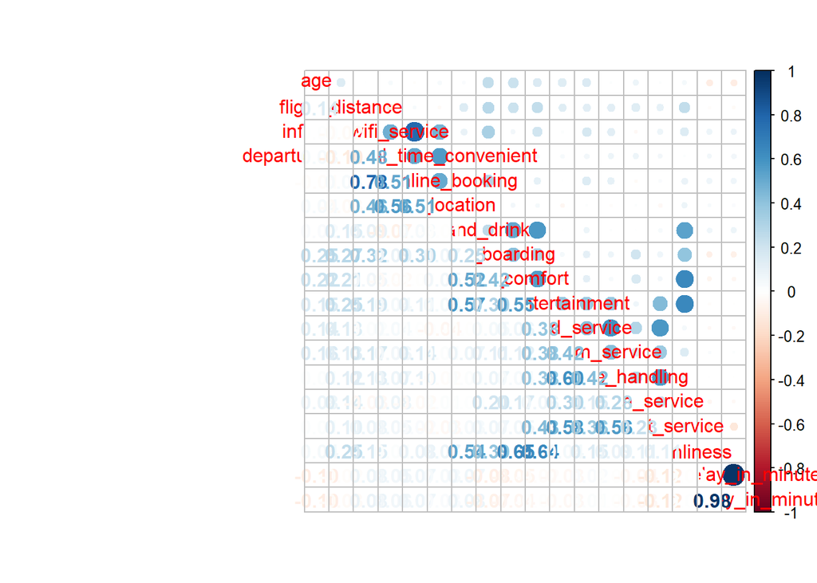

```r
data_nona |>
  select(where(is.numeric)) |>
  cor(use = "pairwise.complete.obs") |>
  corrplot::corrplot.mixed()
```

```r
data_nona <- data_nona |>
  mutate(delay_max = pmax(departure_delay_in_minutes, arrival_delay_in_minutes))
```

Departure delay and arrival delay have correlation of .98, we’re going to make a new variable called delay_max that simply takes the maximum delay value of either departure or arrival for each participant. This seems preferable to taking the mean of the two as we expect that satisfaction is likely to be largely driven by the worst delay-related experience. Keeping both provides very little additional information and would mean we have high multicollinearity.

## Fitting & Evaluating models

### Splitting data

```r
set.seed(123)

split <- initial_split(data_nona, prop = 0.8, strata = satisfaction)

train_data <- training(split)
test_data  <- testing(split)
```

We’ll want a performance estimate of our model on held-out data, so we split the data here, will only touch the training data. Since we have 419 observations it seems setting aside 20% as held-out will be just fine here. Making our training set any smaller may inflate bias and making the held-out set smaller might give is a high variance estimate, to combat this we will additionally perform repeated kfold cross-validation on the training set, using that final held-out 20% as a pure test set/final check. We considered a single validation or nested cross-validation approach as well, but due to high variance and unnecessary complexity we decided against them. We’ll do 5 folds as we don’t want to do too many since having the sample sizes within each split be any smaller may cause variance problems, and we’ll do 10 repeats for additional variance reduction, but not any more for computational cost/time considerations.

### Cross-validation setup/folds

```r
folds <- vfold_cv(train_data, v = 5, repeats = 10, strata = satisfaction)
```

### Recipe

```r
rec <- recipe(satisfaction ~ ., data = train_data) |>
  step_rm(c("id", "departure_delay_in_minutes", "arrival_delay_in_minutes")) |>
  step_dummy(all_nominal_predictors()) |>
  step_zv(all_predictors()) |>
  step_normalize(all_numeric_predictors())
```

### Model Specification & Workflow

```r
m1_log_reg <- logistic_reg(
  penalty = tune(),
  mixture = tune()) |>
  set_engine("glmnet")

wf <- workflow() |>
  add_recipe(rec) |>
  add_model(m1_log_reg)
```

We’re choosing to tune a glmnet as it gives us a simple, interpretable, and semi-flexible classification model (flexible in terms of regularization and potentially feature selection, though still assumes linear DGP). If this linear classsification baseline performs poorly, we’ll likely transition to a nonparametric approach. We then combine the preprocessing recipe and model specification into a workflow so that the preprocessing steps are concisely and consistently applied within our cross-validation folds.

### Hyperparameter Grid

```r
grid <- grid_regular(
  penalty(range = c(-3, -1)),
  mixture(),
  levels = 5)
```

We define a tuning grid for the penalty and mixture hyperparameters. We started with a more coarse grid before refining our search for optimal penalty values, we find that small to moderate penalties are ideal. This left us with -3 to -1 (log scale) as our penalty consideration range. The mixture simply tries different blends of L2 and L1 regularization, along with pure L2 and pure L1.

### Tuning

```r
# About 2 minutes
tuned_results <- tune_grid(
  wf,
  resamples = folds,
  grid = grid,
  metrics = metric_set(roc_auc, specificity, accuracy))
```

### Results

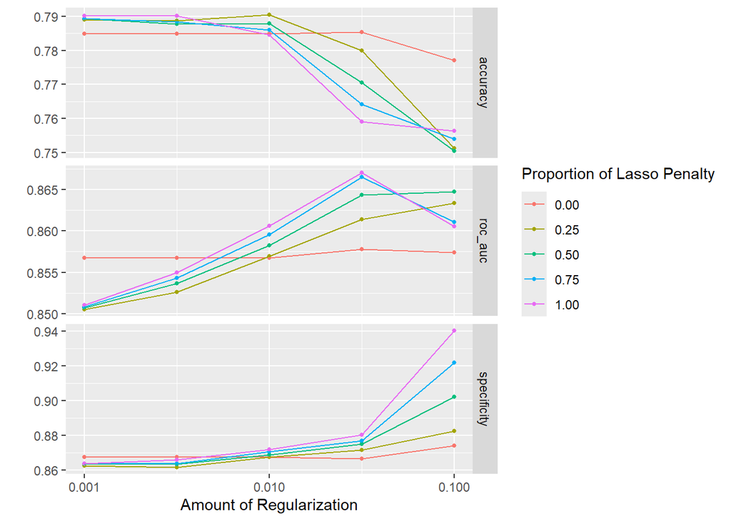

```r
autoplot(tuned_results)
```

```r
tuned_results |>
  collect_metrics() |>
  select(penalty, mixture, .metric, mean) |>
  pivot_wider(names_from = .metric, values_from = mean) |>
  arrange(desc(roc_auc)) |>
  slice_head(n = 20)
```

```
# A tibble: 20 × 5
   penalty mixture accuracy roc_auc specificity
     <dbl>   <dbl>    <dbl>   <dbl>       <dbl>
 1 0.0316     1       0.759   0.867       0.880
 2 0.0316     0.75    0.764   0.866       0.877
 3 0.1        0.5     0.750   0.865       0.902
 4 0.0316     0.5     0.770   0.864       0.875
 5 0.1        0.25    0.751   0.863       0.883
 6 0.0316     0.25    0.780   0.861       0.871
 7 0.1        0.75    0.754   0.861       0.922
 8 0.01       1       0.785   0.861       0.872
 9 0.1        1       0.756   0.861       0.940
10 0.01       0.75    0.786   0.860       0.871
11 0.01       0.5     0.788   0.858       0.869
12 0.0316     0       0.785   0.858       0.867
13 0.1        0       0.777   0.857       0.874
14 0.01       0.25    0.791   0.857       0.867
15 0.001      0       0.785   0.857       0.867
16 0.00316    0       0.785   0.857       0.867
17 0.01       0       0.785   0.857       0.867
18 0.00316    1       0.790   0.855       0.866
19 0.00316    0.75    0.788   0.854       0.864
20 0.00316    0.5     0.788   0.854       0.863
```

### Fit our best model to the full training data and evaluate on held-out data

```r
best_params <- tibble(
  penalty = 0.1,
  mixture = 1)

final_wf <- finalize_workflow(wf, best_params)

final_model <- fit(final_wf, data = train_data)

preds <- predict(final_model, test_data, type = "prob") |>
  bind_cols(predict(final_model, test_data, type = "class")) |>
  bind_cols(test_data)
```

### Held-out performance

```r
roc_auc(preds, truth = satisfaction, .pred_0)
```

```
# A tibble: 1 × 3
  .metric .estimator .estimate
  <chr>   <chr>          <dbl>
1 roc_auc binary         0.846
```

```r
spec(preds, truth = satisfaction, estimate = .pred_class)
```

```
# A tibble: 1 × 3
  .metric .estimator .estimate
  <chr>   <chr>          <dbl>
1 spec    binary         0.930
```

Evaluating our model on test we see that there was some slight optimization bias in our earlier performance estimate, but only marginally so. We still had an extremely good specificity of .93 and an acceptable auROC of .846. Our model seems to be quite low variance if we compare these to the earlier values of .94 and .86. Our bias is still quite low, though I’d make the argument that we don’t mind it being where it is as there’s such a low cost to reaching out to additional customers. However, if we are providing compensation or travel vouchers based upon the model, this would change quite a bit. Depending on what we want we could make the necessary changes, but this appears to serve as a fantastic baseline model.

```r
fullglmnet_fit <- final_model$fit$fit$fit
coefficients <- coef(fullglmnet_fit, s = 0.1)

coefficients <- as.matrix(coefficients)
coefficients <- data.frame(
  term = rownames(coefficients),
  estimate = coefficients[,1])

coefficients
```

```
                                                               term
(Intercept)                                             (Intercept)
age                                                             age
flight_distance                                     flight_distance
inflight_wifi_service                         inflight_wifi_service
departure_arrival_time_convenient departure_arrival_time_convenient
ease_of_online_booking                       ease_of_online_booking
gate_location                                         gate_location
food_and_drink                                       food_and_drink
online_boarding                                     online_boarding
seat_comfort                                           seat_comfort
inflight_entertainment                       inflight_entertainment
onboard_service                                     onboard_service
leg_room_service                                   leg_room_service
baggage_handling                                   baggage_handling
checkin_service                                     checkin_service
inflight_service                                   inflight_service
cleanliness                                             cleanliness
delay_max                                                 delay_max
gender_X1                                                 gender_X1
customer_type_X1                                   customer_type_X1
type_of_travel_X1                                 type_of_travel_X1
customer_class_1                                   customer_class_1
customer_class_2                                   customer_class_2
                                      estimate
(Intercept)                        0.759336701
age                                0.000000000
flight_distance                    0.006232991
inflight_wifi_service              0.000000000
departure_arrival_time_convenient  0.000000000
ease_of_online_booking             0.000000000
gate_location                      0.000000000
food_and_drink                     0.000000000
online_boarding                    0.260454027
seat_comfort                       0.000000000
inflight_entertainment             0.095860015
onboard_service                    0.000000000
leg_room_service                   0.000000000
baggage_handling                   0.000000000
checkin_service                    0.000000000
inflight_service                   0.000000000
cleanliness                        0.000000000
delay_max                          0.000000000
gender_X1                          0.000000000
customer_type_X1                   0.000000000
type_of_travel_X1                 -0.426792723
customer_class_1                   0.065387423
customer_class_2                   0.000000000
```

```r
coefficients_used <- coefficients[coefficients$estimate != 0, ]

coefficients_used
```

```
                                         term     estimate
(Intercept)                       (Intercept)  0.759336701
flight_distance               flight_distance  0.006232991
online_boarding               online_boarding  0.260454027
inflight_entertainment inflight_entertainment  0.095860015
type_of_travel_X1           type_of_travel_X1 -0.426792723
customer_class_1             customer_class_1  0.065387423
```

## Prediction summary:

### Spending your data:

We split the dataset into an 80/20 train–test split using stratification on the outcome to preserve class balance. The training set was used for all model fitting and model selection, while the test set was held out as a final, unbiased estimate of model performance. Within the training data, we used repeated 5-fold cross-validation (10 repeats) to evaluate model configurations. This approach balances bias and variance trade-off considerations. Holding out a test set prevents optimization bias in performance estimates, while repeated cross-validation reduces the variance of model evaluation compared to a single split. Given the moderate sample size (n = 419 after casewise deletion), this strategy allows us to efficiently use the data while still maintaining a reliable estimate of generalization performance. The main tradeoff is that reserving 20% of the data reduces the amount available for model fitting, potentially increasing bias slightly. However, this is mitigated by cross-validation, and the benefit of having a clean, unbiased test evaluation outweighs this cost.

### Model configurations:

We focused on a regularized logistic regression model (glmnet), tuning two key hyperparameters: the penalty, which controls the strength of regularization, and the mixture parameter, which determines the balance between ridge (L2) and lasso (L1) penalties. We explored a range of penalty values (on a log scale) and multiple mixture values spanning ridge to lasso, beginning with a broader grid and then refining to smaller penalty values where performance was strongest. This ensured that we considered models ranging from L2 regularization with little to no penalty all the way to large penalties and L1 regularization/feature selection. We determined that we had explored a sufficient range when performance was less variable (in terms of auROC, specificity, and accuracy) across a region of hyperparameters, indicating that further expansion of the grid was unlikely to yield meaningful improvements. Earlier grid values showed sporatic and massive decreases in these metrics. Additionally, comparing ridge, lasso, and elastic net configurations ensured that both shrinkage-based and feature-selection-based models were considered.